# Bayesian Regression Review PCA

## Markov Chains

You manage 10 teams, named from 1 to 10. Each team name is proportional to the number of people on the team and each team is on a separate floor in the building.

You need to visit a team everyday, proportional to the number of people on the team (i.e., you would visit team 10 more often than team 1).

At the end of the day, you randomly select whether a proposed move will take you up a floor or down a floor.

After randomly selecting up or down, you grab a number of pens that is equal to the number of the current team (for team 10, you would grab 10 pens).

Next, you would grab a number of pencils corresponding to the proposed move (your randomly selected proposal would take you up a floor, so starting back at the bottom with team 1). So you would have 10 pens and 1 pencil.

If you have more pencils than pens, you will always move to the proposed floor.

If you have more pens than pencils, you set down a number of pens equal to the number of pencils and put them in a drawer.

You reach back into the drawer to randomly select a pen or a pencil.

Your selection decides where you go – pen is stay and pencil is go!

```r
days = 1000

position = rep(0, days)

current = 10

for(i in 1:days) {
  position[i] = current

  proposal = current + sample(c(-1, 1), size = 1)

  if(proposal < 1) proposal = 10

  if(proposal > 10) proposal = 1

  probabilityMove = proposal / current

  current = ifelse(runif(1) < probabilityMove, proposal, current)

  # print(paste(position[i], proposal, probabilityMove, current, sep = " -> "))
}
```

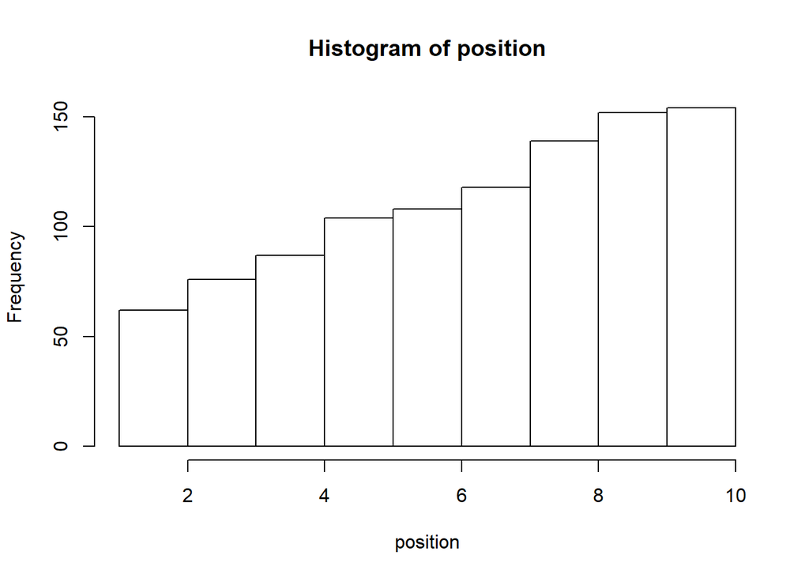

```r
hist(position)
```

Does this look familiar?

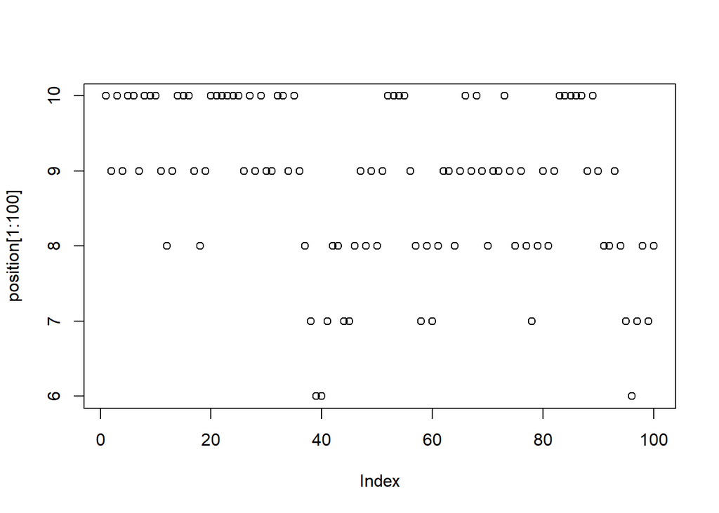

```r
plot(position[1:100])
```

Might it look like this:

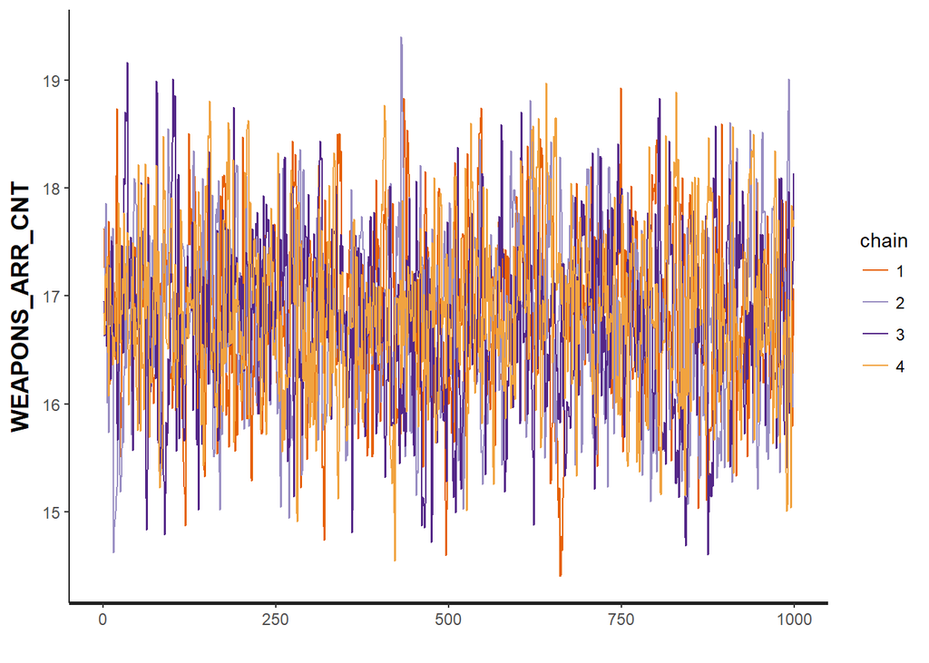

```r
library(dplyr)

library(rstanarm)

library(ggplot2)

crimeScore = readr::read_csv("http://nd.edu/~sberry5/data/crimeScore.csv")

crimeScore = crimeScore %>%
  filter(SEX_CODE_CD != "X")

blm = stan_lm(SSL_SCORE ~ WEAPONS_ARR_CNT,
              data = crimeScore,
              prior = R2(.1, "mean"), seed = 10001, chains = 4,
              cores = (parallel::detectCores() - 1),
              iter = 2000)

rstan::stan_trace(blm, pars = "WEAPONS_ARR_CNT")
```

It might help to break them apart:

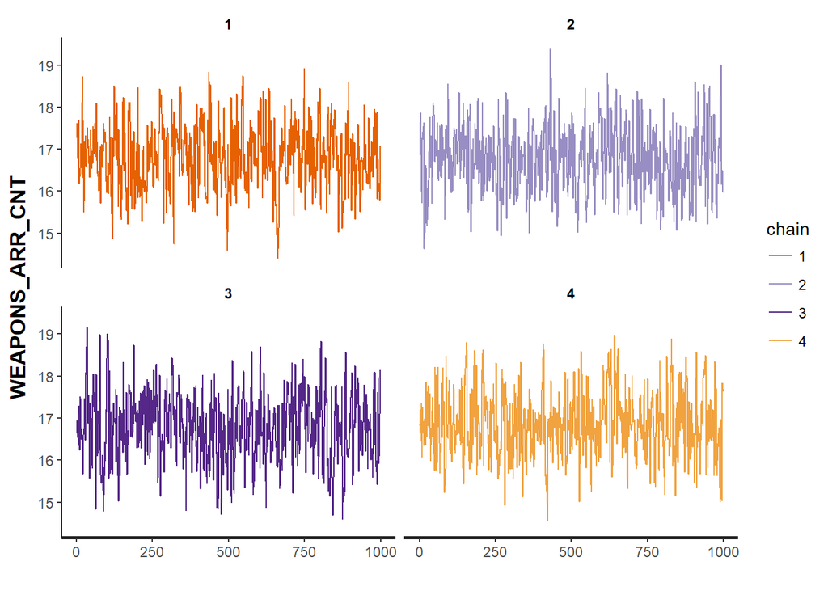

```r
rstan::stan_trace(blm, pars = "WEAPONS_ARR_CNT") +
  facet_wrap( ~ chain, nrow = 2)
```

```r
summary(blm)
```

```
Model Info:

 function:     stan_lm
 family:       gaussian [identity]
 formula:      SSL_SCORE ~ WEAPONS_ARR_CNT
 algorithm:    sampling
 priors:       see help('prior_summary')
 sample:       4000 (posterior sample size)
 observations: 19145
 predictors:   2

Estimates:
                  mean      sd        2.5%      25%       50%
(Intercept)         300.2       1.0     298.2     299.5     300.2
WEAPONS_ARR_CNT      16.8       0.8      15.3      16.3      16.8
sigma                53.0       0.3      52.5      52.9      53.0
log-fit_ratio         0.1       0.0       0.1       0.1       0.1
R2                    0.0       0.0       0.0       0.0       0.0
mean_PPD            320.5       0.5     319.4     320.1     320.5
log-posterior   -103194.4       1.2 -103197.6 -103195.0 -103194.1
                  75%       97.5%
(Intercept)         300.8     302.2
WEAPONS_ARR_CNT      17.3      18.3
sigma                53.2      53.6
log-fit_ratio         0.1       0.1
R2                    0.0       0.0
mean_PPD            320.8     321.5
log-posterior   -103193.5 -103193.1

Diagnostics:
                mcse Rhat n_eff
(Intercept)     0.0  1.0  1118
WEAPONS_ARR_CNT 0.0  1.0  1141
sigma           0.0  1.0  1696
log-fit_ratio   0.0  1.0  1311
R2              0.0  1.0  1168
mean_PPD        0.0  1.0  3829
log-posterior   0.0  1.0  1219

For each parameter, mcse is Monte Carlo standard error, n_eff is a crude measure of effective sample size, and Rhat is the potential scale reduction factor on split chains (at convergence Rhat=1).
```

# PCA – Briefly

Some of you might have found data with many predictor variables. When you start looking at these predictor variables, you might start to think that there could be interesting ways to reduce them down into fewer variables. We can do this by taking linear combinations of the variables. PCA will find the first linear combination of variables that account for the most variability within the data. There is no underlying model for the components and the correlation diagonals between components and items are 1.

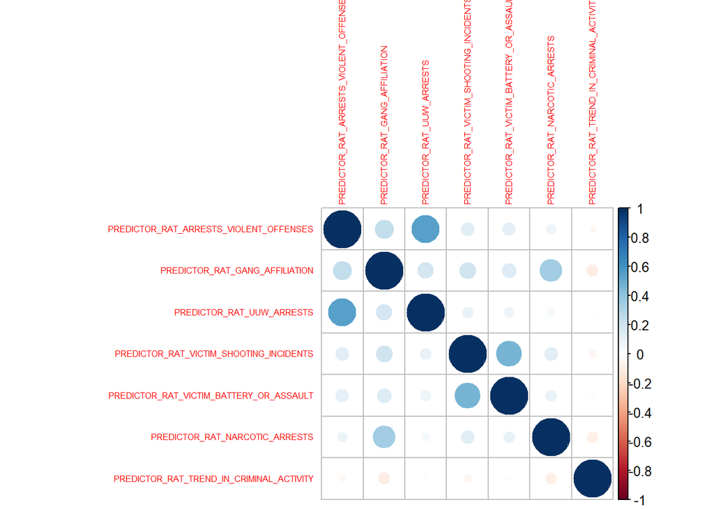

```r
crimeScore = crimeScore %>%
  select(starts_with("predictor"), SSL_SCORE, SEX_CODE_CD,
         -PREDICTOR_RAT_AGE_AT_LATEST_ARREST)

crimeScore %>%
  select(-SEX_CODE_CD, -SSL_SCORE) %>%
  cor(.) %>%
  corrplot::corrplot(., order = "FPC", tl.cex = .5)
```

There are two main types of PCA: spectral decomposition and singular value decomposition (SVD).

Spectral works over the variables, SVD works over the individuals.

Let’s look at a spectral first:

```r
pcaTestSpec = crimeScore %>%
  select(-SSL_SCORE, -SEX_CODE_CD) %>%
  princomp(., cor = TRUE, scores = TRUE)
```

We can see each components eigenvalue:

```r
pcaTestSpec$sdev^2
```

```
   Comp.1    Comp.2    Comp.3    Comp.4    Comp.5    Comp.6    Comp.7
1.9934601 1.3128782 1.1445683 0.9490821 0.6258055 0.5279136 0.4462921
```

Factor loadings are the correlation between the variable and the component:

```r
pcaTestSpec$loadings
```

```
Loadings:
                                         Comp.1 Comp.2 Comp.3 Comp.4
PREDICTOR_RAT_VICTIM_SHOOTING_INCIDENTS  -0.405  0.463  0.315
PREDICTOR_RAT_VICTIM_BATTERY_OR_ASSAULT  -0.372  0.466  0.394
PREDICTOR_RAT_ARRESTS_VIOLENT_OFFENSES   -0.465 -0.484  0.144
PREDICTOR_RAT_GANG_AFFILIATION           -0.445        -0.413 -0.235
PREDICTOR_RAT_NARCOTIC_ARRESTS           -0.304  0.198 -0.589 -0.356
PREDICTOR_RAT_TREND_IN_CRIMINAL_ACTIVITY  0.117         0.422 -0.895
PREDICTOR_RAT_UUW_ARRESTS                -0.422 -0.535  0.170
                                         Comp.5 Comp.6 Comp.7
PREDICTOR_RAT_VICTIM_SHOOTING_INCIDENTS          0.718
PREDICTOR_RAT_VICTIM_BATTERY_OR_ASSAULT   0.113 -0.684
PREDICTOR_RAT_ARRESTS_VIOLENT_OFFENSES                  0.723
PREDICTOR_RAT_GANG_AFFILIATION           -0.740 -0.102 -0.129
PREDICTOR_RAT_NARCOTIC_ARRESTS            0.625
PREDICTOR_RAT_TREND_IN_CRIMINAL_ACTIVITY
PREDICTOR_RAT_UUW_ARRESTS                 0.215        -0.674

               Comp.1 Comp.2 Comp.3 Comp.4 Comp.5 Comp.6 Comp.7
SS loadings     1.000  1.000  1.000  1.000  1.000  1.000  1.000
Proportion Var  0.143  0.143  0.143  0.143  0.143  0.143  0.143
Cumulative Var  0.143  0.286  0.429  0.571  0.714  0.857  1.000
```

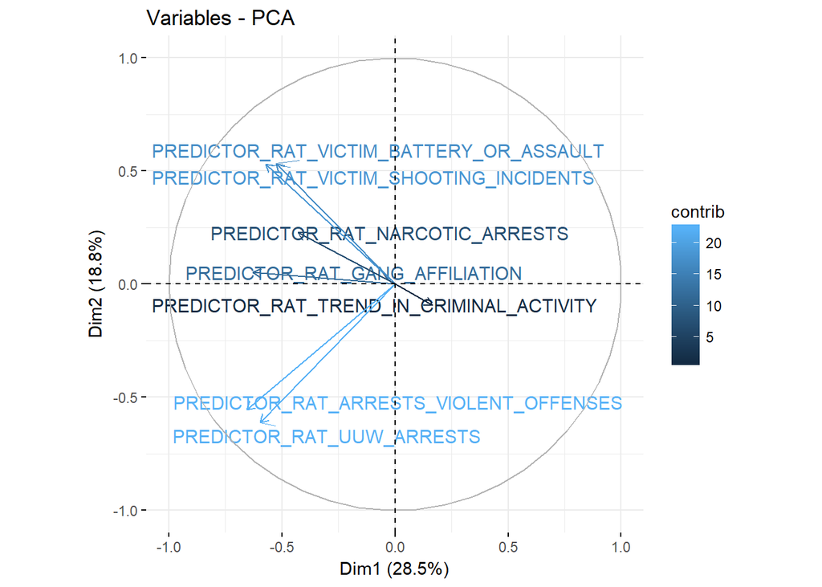

```r
factoextra::fviz_pca_var(pcaTestSpec,
                         col.var = "contrib",
                         repel = TRUE)
```

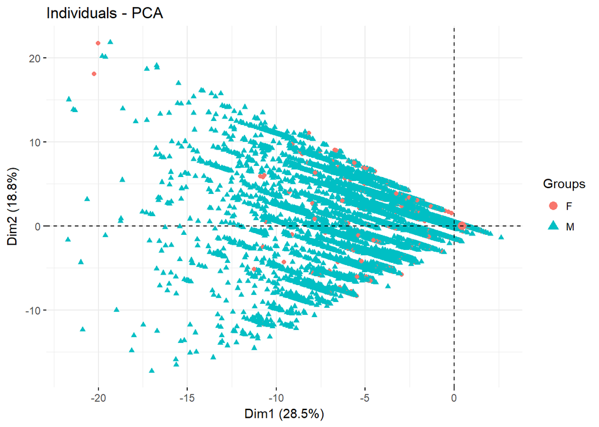

```r
factoextra::fviz_pca_ind(pcaTestSpec, geom = "point",
                         habillage = crimeScore$SEX_CODE_CD)
```

```r
crimeScoresPCA = cbind(crimeScore, pcaTestSpec$scores)

lm(SSL_SCORE ~ Comp.1, data = crimeScoresPCA) %>%
  summary()
```

```
Call:
lm(formula = SSL_SCORE ~ Comp.1, data = crimeScoresPCA)

Residuals:
     Min       1Q   Median       3Q      Max
-281.567  -35.184    9.783   42.147  234.099

Coefficients:
             Estimate Std. Error t value Pr(>|t|)
(Intercept) 279.84170    0.08628  3243.4   <2e-16 ***
Comp.1      -14.09456    0.06111  -230.6   <2e-16 ***
---
Signif. codes:  0 '***' 0.001 '**' 0.01 '*' 0.05 '.' 0.1 ' ' 1

Residual standard error: 54.47 on 398625 degrees of freedom
Multiple R-squared:  0.1177,    Adjusted R-squared:  0.1177
F-statistic: 5.32e+04 on 1 and 398625 DF,  p-value: < 2.2e-16
```

And now SVD:

```r
pcaTestSVD = crimeScore %>%
  select(-SSL_SCORE, -SEX_CODE_CD) %>%
  prcomp(., center = TRUE, scale. = TRUE)
```

In our summary we have our loadings:

```r
pcaTestSVD
```

```
Standard deviations (1, .., p=7):
[1] 1.4118995 1.1458090 1.0698450 0.9742085 0.7910787 0.7265766 0.6680510

Rotation (n x k) = (7 x 7):
                                                PC1         PC2        PC3
PREDICTOR_RAT_VICTIM_SHOOTING_INCIDENTS   0.4045767 -0.46336935  0.3150253
PREDICTOR_RAT_VICTIM_BATTERY_OR_ASSAULT   0.3716165 -0.46624910  0.3944647
PREDICTOR_RAT_ARRESTS_VIOLENT_OFFENSES    0.4650121  0.48397533  0.1437509
PREDICTOR_RAT_GANG_AFFILIATION            0.4445311 -0.04488602 -0.4134058
PREDICTOR_RAT_NARCOTIC_ARRESTS            0.3043193 -0.19841214 -0.5890371
PREDICTOR_RAT_TREND_IN_CRIMINAL_ACTIVITY -0.1174728  0.08082417  0.4216179
PREDICTOR_RAT_UUW_ARRESTS                 0.4218584  0.53455947  0.1698872
                                                 PC4         PC5
PREDICTOR_RAT_VICTIM_SHOOTING_INCIDENTS  -0.07569451  0.03223064
PREDICTOR_RAT_VICTIM_BATTERY_OR_ASSAULT  -0.07073509 -0.11270075
PREDICTOR_RAT_ARRESTS_VIOLENT_OFFENSES   -0.05287928 -0.03276606
PREDICTOR_RAT_GANG_AFFILIATION            0.23524169  0.73968142
PREDICTOR_RAT_NARCOTIC_ARRESTS            0.35636225 -0.62507134
PREDICTOR_RAT_TREND_IN_CRIMINAL_ACTIVITY  0.89454524  0.03128966
PREDICTOR_RAT_UUW_ARRESTS                -0.06266401 -0.21532369
                                                 PC6          PC7
PREDICTOR_RAT_VICTIM_SHOOTING_INCIDENTS  -0.71761961 -0.024883914
PREDICTOR_RAT_VICTIM_BATTERY_OR_ASSAULT   0.68421383  0.055291065
PREDICTOR_RAT_ARRESTS_VIOLENT_OFFENSES    0.04195167 -0.723351562
PREDICTOR_RAT_GANG_AFFILIATION            0.10206147  0.128799014
PREDICTOR_RAT_NARCOTIC_ARRESTS           -0.02271329 -0.053231277
PREDICTOR_RAT_TREND_IN_CRIMINAL_ACTIVITY -0.02607626 -0.005977055
PREDICTOR_RAT_UUW_ARRESTS                -0.05917076  0.673518914
```

We can also get the eigenvalues for each component:

```r
pcaTestSVD$sdev^2
```

```
[1] 1.9934601 1.3128782 1.1445683 0.9490821 0.6258055 0.5279136 0.4462921
```

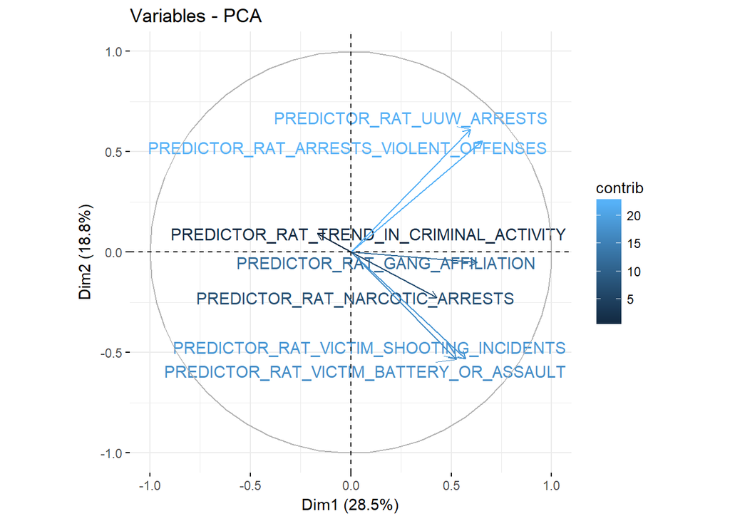

```r
factoextra::fviz_pca_var(pcaTestSVD,
                         col.var = "contrib",
                         repel = TRUE)
```